### Introduction

This article presents a sample data analysis using methods described in two separate articles/tutorial papers (Masaki 2010) (DiStefano, Zhu, and Mindrila 2009). The aims are:

1. Questionnaire validation
   - Explore the **empirical correlations** between our items; not just theorectical correlations (some questionnaire items might end up capturing none or more than one trait and we can’t perform hypothesis testing with that item)
   - It allows us to trim away some items or construct new factors (traits) to explain our data
   - Sometime there are traits that are not measured at all properly by all our survey questions (and we have to add some).
2. Optimal scaling
   - a composite measure of a particular domain can be calculated and used for subsequent analyses

**Our general workflow**:

1. PCA screening
2. EFA (Parallel Analysis, Screening, Factor Analysis)
3. Regression modeling

### Methods

An **artificial dataset** containing 500 observations of 15 questions was generated to simulate a 15 question-long survey form conducted on (n=500) respondents. They are designed as if asking about two different themes on a 7 point Likert-type scale.

Knowledge:

- Q1-3 are highly correlated (*r<sub>pc</sub>* > 0.70)
- Q3-6 are moderately correlated (0.50 < *r<sub>pc</sub>* < 0.60)

Behaviour:

- Q10-12 are highly correlated (*r<sub>pc</sub>* > 0.70)
- Q13-15 are moderately correlated (0.50 < *r<sub>pc</sub>* < 0.60)

Noise:

- Q7-9 are pure noise (*r<sub>pc</sub>* < 0.10)

Note: *r<sub>pc</sub>* stands for Polychoric correlation coefficient (Ekström 2011)

The questions were designed on the premise that:

1. The first 3 questions in each group are high quality and correlate highly with each other
2. The next 3 questions in each group are lower quality and only moderately correlated with each other
3. Q7-9 are pure noise and represent very poorly designed variables

**Responses were coded (Strongly Disagree = -3 to Strongly Agree = 3)**

```
##   Q1 Q2 Q3 Q4 Q5 Q6 Q7 Q8 Q9 Q10 Q11 Q12 Q13 Q14 Q15
## 1  1 -1 -1 -2  0  0  3 -3  1  -1   1   1  -2   1   2
## 2  2  0  0 -1  1  0 -2 -1  3  -1   0   0  -1  -1   0
## 3  2  0  1 -1  2 -2 -2 -2  1  -2   0   0   1   2  -1
## 4  3  1  1  1  2  0 -1  3  1  -3  -2  -1   1   1   2
## 5  1  0  0 -2 -1  0 -2 -1 -1  -1   0   0   0   0   1
## 6  3  1  2 -1  0  2  1 -1 -3  -3  -1  -1  -1  -2  -1
```

All analyses were performed using R: A language and environment for statistical computing (R Core Team 2014). Polychoric correlation matrices were calcuated using the “polycor” package (Fox 2010). Functions from the “psych” packages were used for factor analysis (Revelle 2014). Parallel analysis was performed with (Presaghi and Desimoni 2014).

### Results and Discussion

#### Step 1a. Generate items

Although artificial data was used in our analysis, the first step in the entire process is actually creating the survey instrument to measure the traits in our theoretical framework.

- Create items (i.e. Questions) that supposedly tap into the target construct
- Questions should be as expansive as possible: maximize face value
- Redundancy at this stage is fine but missing items is serious

#### Step 1b Screening items

The data set (n=500) was partioned into a training set (n=200) and test set (n=300) via simple random sampling to reduce bias. The training set was used for for item screening via PCA.

```r
index <- sample(nrow(data), 200)
train <- data[index, ]
test <- data[-index,]
test.original <- test
```

Non-linear principal components analysis with promax rotation was performed:

- We look for variables that load clearly onto one component
- Try to minimize cross-loading: i.e. high loadings on >1 component
- A cut-off that is generally accepted (but should be reported)
1. More than 0.50-0.60 on main factor and <0.20-0.30 on others
2. We can discard questions that don’t meet this criteria
- *Make sure that the results make theorectical sense!*

```
## Principal Components Analysis
## Call: principal(r = train.cor$correlations, nfactors = 10, rotate = "promax")
## Standardized loadings (pattern matrix) based upon correlation matrix
##       PC2   PC1   PC4   PC3   PC6   PC9   PC5  PC10   PC7   PC8   h2
## Q1   0.87 -0.10 -0.03  0.02  0.08  0.15 -0.02 -0.02  0.07  0.00 0.91
## Q2   0.85 -0.19  0.00 -0.15  0.06  0.08  0.02  0.09  0.16  0.14 0.90
## Q3   0.93 -0.12 -0.07  0.00  0.17  0.03  0.01  0.06 -0.02  0.05 0.85
## Q4   0.22  0.15  0.03  0.05 -0.11  0.95  0.00 -0.04 -0.08 -0.07 0.97
## Q5   0.83  0.23  0.06  0.06 -0.32 -0.15  0.00 -0.05 -0.09 -0.10 0.92
## Q6   0.18  0.14  0.02  0.06 -0.09 -0.08 -0.01 -0.06  0.93 -0.07 0.98
## Q7   0.01  0.01  0.00  0.01 -0.01 -0.01  1.00 -0.02 -0.01 -0.01 1.00
## Q8  -0.07 -0.10 -0.02  0.98  0.06  0.05  0.01  0.05  0.06  0.06 0.99
## Q9  -0.06 -0.06  1.01 -0.02  0.05  0.03  0.00  0.02  0.02  0.03 0.99
## Q10 -0.13  0.85 -0.07 -0.04  0.11  0.01  0.00  0.08  0.06  0.10 0.90
## Q11 -0.12  0.84  0.00 -0.07  0.04  0.07  0.04  0.17  0.09  0.01 0.87
## Q12 -0.05  0.94 -0.01 -0.02  0.09  0.10 -0.02 -0.11  0.02  0.06 0.89
## Q13  0.10  0.23  0.03  0.06 -0.10 -0.07 -0.01 -0.05 -0.07  0.94 0.98
## Q14  0.08  0.16  0.02  0.05 -0.06 -0.04 -0.02  0.94 -0.06 -0.05 0.98
## Q15  0.20  0.39  0.06  0.07  0.89 -0.13 -0.01 -0.06 -0.09 -0.10 0.93
##          u2
## Q1  0.09444
## Q2  0.09966
## Q3  0.15056
## Q4  0.03024
## Q5  0.07679
## Q6  0.02104
## Q7  0.00071
## Q8  0.01380
## Q9  0.00626
## Q10 0.10339
## Q11 0.12625
## Q12 0.11260
## Q13 0.02303
## Q14 0.01813
## Q15 0.07064
##
##                        PC2  PC1  PC4  PC3  PC6  PC9  PC5 PC10  PC7  PC8
## SS loadings           3.29 2.89 1.02 1.01 0.95 0.99 1.00 0.99 0.97 0.95
## Proportion Var        0.22 0.19 0.07 0.07 0.06 0.07 0.07 0.07 0.06 0.06
## Cumulative Var        0.22 0.41 0.48 0.55 0.61 0.68 0.74 0.81 0.87 0.94
## Proportion Explained  0.23 0.21 0.07 0.07 0.07 0.07 0.07 0.07 0.07 0.07
## Cumulative Proportion 0.23 0.44 0.51 0.58 0.65 0.72 0.79 0.86 0.93 1.00
##
##  With component correlations of
##        PC2  PC1   PC4   PC3   PC6   PC9  PC5 PC10  PC7   PC8
## PC2   1.00 0.22  0.17  0.07  0.02  0.32 0.05 0.05 0.38 -0.06
## PC1   0.22 1.00  0.17  0.13  0.20  0.01 0.08 0.43 0.09  0.36
## PC4   0.17 0.17  1.00  0.12 -0.02 -0.03 0.06 0.03 0.11  0.01
## PC3   0.07 0.13  0.12  1.00 -0.03  0.04 0.21 0.14 0.06  0.07
## PC6   0.02 0.20 -0.02 -0.03  1.00  0.39 0.04 0.33 0.30  0.40
## PC9   0.32 0.01 -0.03  0.04  0.39  1.00 0.01 0.24 0.37  0.17
## PC5   0.05 0.08  0.06  0.21  0.04  0.01 1.00 0.00 0.07  0.11
## PC10  0.05 0.43  0.03  0.14  0.33  0.24 0.00 1.00 0.15  0.30
## PC7   0.38 0.09  0.11  0.06  0.30  0.37 0.07 0.15 1.00  0.18
## PC8  -0.06 0.36  0.01  0.07  0.40  0.17 0.11 0.30 0.18  1.00
##
## Test of the hypothesis that 10 components are sufficient.
##
## The degrees of freedom for the null model are  105  and the objective function was  8.86
## The degrees of freedom for the model are 0  and the objective function was  2.81
##
## Fit based upon off diagonal values = 0.99
```

#### Step 2. Exploratory Factor Analysis using the test set (n=300)

1. Determine number of factors underlying the data
2. Identify which variables load on to which factors
3. Remove variables which do not load onto any factors

*New data should be used*, the remaining observations i.e. the test set (n=300) will be used or the next part.

#### EFA: Parallel analysis

1. 500-1000 artificial datasets are generated with the same number of variables and same number of observations
   - Note: 10 were used in this sample analysis to save time; the 10 simulations took 1 minute (500 will take ~1 hr and 1000 will take ~2hrs)
2. Variables in these datasets are random variables
3. Factor analysis is performed on each of these datasets and the eigenvalues of each factor generated are extracted
4. Repeating this many times will allow us to calculate the mean eigenvalue of a factor from datasets similar to what we have
5. An eigenvalue less than the mean would mean that a particular factor extracted is no more substantial (explains less) than a random factor (which really has no meaning); those factors are rejected

```r
random.polychor.pa(nrep=10, data.matrix=data.matrix(test), q.eigen = 0.99, r.seed = 1, diff.fact=TRUE, distr="NULL", comparison = "random", fit.pa=FALSE, print.all=FALSE)
```

[output not shown]

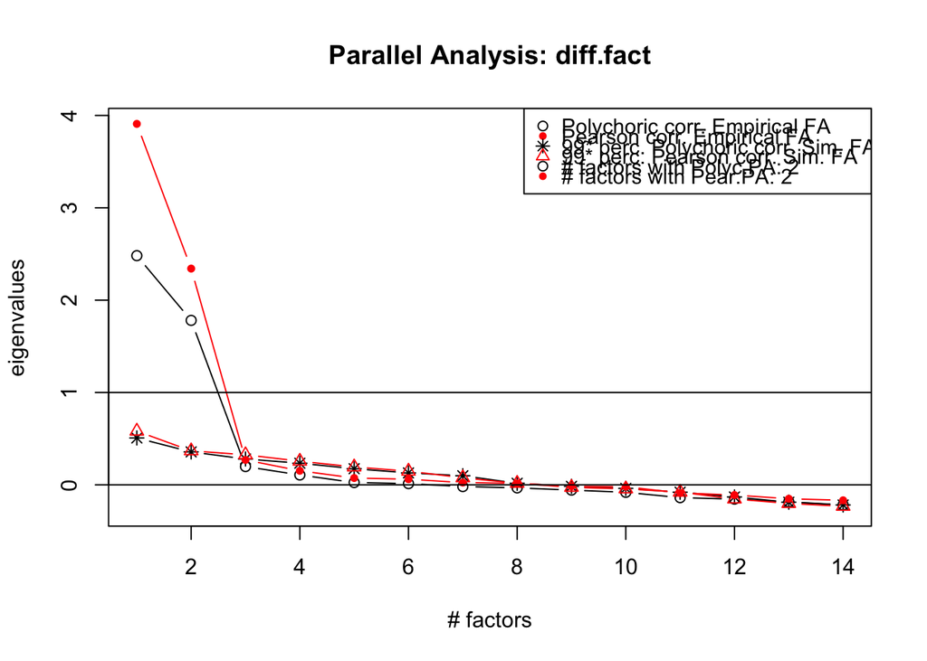

```r
#
```

**Parallel analysis suggests that 2 factors are to be extracted**. Factor analysis was performed with the number of factors selected by Parallel Analysis.

#### EFA: Screening items

```r
test.cor <- hetcor(test, ML=F, std.err=F)
test.fa <- fa(r=test.cor$correlations,nfactors=2,rotate="promax")
test.fa
```

```
## Factor Analysis using method =  minres
## Call: fa(r = test.cor$correlations, nfactors = 2, rotate = "promax")
## Standardized loadings (pattern matrix) based upon correlation matrix
##       MR1   MR2     h2   u2 com
## Q1  -0.07  0.93 0.8418 0.16 1.0
## Q2   0.04  0.88 0.8022 0.20 1.0
## Q3   0.02  0.89 0.8078 0.19 1.0
## Q4  -0.05  0.59 0.3379 0.66 1.0
## Q6   0.07  0.54 0.3104 0.69 1.0
## Q7   0.06  0.07 0.0107 0.99 1.9
## Q8  -0.01  0.05 0.0025 1.00 1.1
## Q9   0.13  0.03 0.0199 0.98 1.1
## Q10  0.94 -0.04 0.8645 0.14 1.0
## Q11  0.88  0.03 0.7893 0.21 1.0
## Q12  0.89 -0.01 0.7833 0.22 1.0
## Q13  0.56 -0.01 0.3153 0.68 1.0
## Q14  0.57 -0.01 0.3262 0.67 1.0
##
##                        MR1  MR2
## SS loadings           3.12 3.09
## Proportion Var        0.24 0.24
## Cumulative Var        0.24 0.48
## Proportion Explained  0.50 0.50
## Cumulative Proportion 0.50 1.00
##
##  With factor correlations of
##      MR1  MR2
## MR1 1.00 0.26
## MR2 0.26 1.00
##
## Mean item complexity =  1.1
## Test of the hypothesis that 2 factors are sufficient.
##
## The degrees of freedom for the null model are  78  and the objective function was  6.7
## The degrees of freedom for the model are 53  and the objective function was  0.4
##
## The root mean square of the residuals (RMSR) is  0.03
## The df corrected root mean square of the residuals is  0.04
##
## Fit based upon off diagonal values = 0.99
## Measures of factor score adequacy
##                                                 MR1  MR2
## Correlation of scores with factors             0.97 0.97
## Multiple R square of scores with factors       0.94 0.94
## Minimum correlation of possible factor scores  0.88 0.88
```

```r
#
```

This step is identical to that performed during PCA

- We look for factors that load clearly onto one component
- Try to minimize cross-loading: i.e. high loadings on >1 component
- A cut-off that is generally accepted (but should be reported)
1. More than 0.50-0.60 on main factor and <0.20-0.30 on others
2. We can discard questions that don’t meet this criteria
- *Make sure that the results make theorectical sense!*

```
## Factor Analysis using method =  minres
## Call: fa(r = test.final.cor$correlations, nfactors = 2, rotate = "promax")
## Standardized loadings (pattern matrix) based upon correlation matrix
##       MR1   MR2   h2    u2 com
## Q1   0.02  0.98 0.96 0.037   1
## Q2   0.06  0.91 0.84 0.156   1
## Q3   0.04  0.92 0.85 0.147   1
## Q4  -0.09  0.64 0.41 0.593   1
## Q6   0.04  0.60 0.37 0.634   1
## Q10  0.98  0.05 0.98 0.021   1
## Q11  0.92  0.05 0.86 0.144   1
## Q12  0.92  0.01 0.84 0.156   1
## Q13  0.59 -0.04 0.34 0.656   1
## Q14  0.60 -0.03 0.35 0.648   1
## Q15  0.65 -0.04 0.42 0.583   1
##
##                        MR1  MR2
## SS loadings           3.80 3.42
## Proportion Var        0.35 0.31
## Cumulative Var        0.35 0.66
## Proportion Explained  0.53 0.47
## Cumulative Proportion 0.53 1.00
##
##  With factor correlations of
##      MR1  MR2
## MR1 1.00 0.09
## MR2 0.09 1.00
##
## Mean item complexity =  1
## Test of the hypothesis that 2 factors are sufficient.
##
## The degrees of freedom for the null model are  55  and the objective function was  37.28
## The degrees of freedom for the model are 34  and the objective function was  27.22
##
## The root mean square of the residuals (RMSR) is  0.06
## The df corrected root mean square of the residuals is  0.08
##
## Fit based upon off diagonal values = 0.97
## Measures of factor score adequacy
##                                                MR1 MR2
## Correlation of scores with factors               1   1
## Multiple R square of scores with factors         1   1
## Minimum correlation of possible factor scores    1   1
```

From the factor analysis above:

#### Step 3. Creating factor scores

- Methods to create factor scores can be divided into non-refined and refined.
- The latter combines PCA and factor extraction methods to creating scores that may be, depending on the method chosen:
  - Highly correlated with a given factor
  - Obtain unbiased estimates of a true factor score
  - Preserves relationships between factors
- Three main methods exist to compute refined factor scores:
  1. Regression Scores - **chosen for demonstration**
  2. Bartlett Scores
  3. Anderson-Rubin Scores - it has been noted that above two have certain issues with subsequent regression analysis (Skrondal and Laake 2001).

#### Step 4. Determining the validity of the factor scores computed (not performed)

- (Grice 2001) suggests researchers examine the degree of indeterminacy in their factor solutions using three different measures:
1. validity – evidence of correlational relationships between factor scores and factor(s)
2. univocality- the extent to which factor scores are adequately or insufficiently correlated with other factors in the same analysis
3. correlational accuracy – which reports the extent to which correlations among the estimated factor scores match the correlations among the factors themselves.

```r
scores <- factor.scores(data.matrix(test.final),f=test.final.fa,method="regression")$scores
test.wscores <- cbind(test.final,scores)
```

#### Step 5. Using the factor scores for regression

- Factors are new variables
- They must be checked for assumptions (e.g. normality) before conducting hypothesis testing
- Regression modeling can be performed with factors as predictors/outcomes

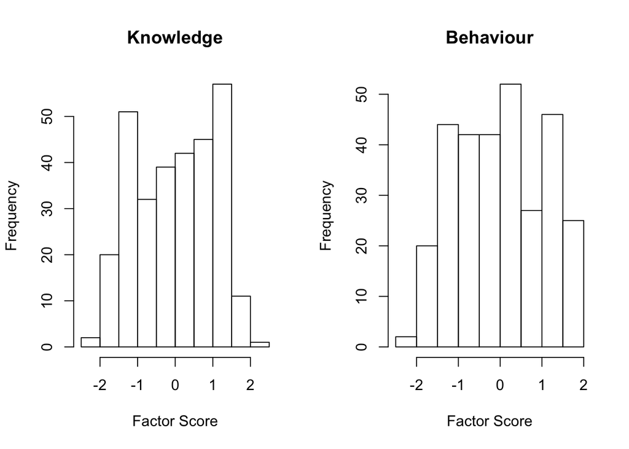

Fitting a linear regression model with the formula:

> H<sub>0</sub>: Β<sub>1</sub> = 0  
> H<sub>a</sub>: Β<sub>1</sub> ≠ 0

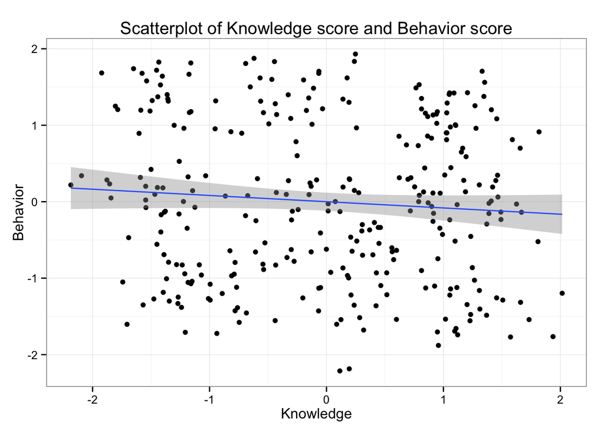

```
##
## Call:
## lm(formula = Factor2 ~ Factor1, data = test.wscores)
##
## Residuals:
##      Min       1Q   Median       3Q      Max
## -2.20352 -0.92126  0.00557  0.98477  1.95116
##
## Coefficients:
##               Estimate Std. Error t value Pr(>|t|)
## (Intercept) -1.036e-16  6.016e-02   0.000    1.000
## Factor1     -8.161e-02  5.765e-02  -1.416    0.158
##
## Residual standard error: 1.042 on 298 degrees of freedom
## Multiple R-squared:  0.006681,   Adjusted R-squared:  0.003348
## F-statistic: 2.004 on 1 and 298 DF,  p-value: 0.1579
```

**We fail to reject H<sub>0</sub> with p = 0.158**

References

DiStefano, Christine, Min Zhu, and Diana Mindrila. 2009. “Understanding and Using Factor Scores: Considerations for the Applied Researcher.” *Practical Assessment, Research & Evaluation* 14 (20): 1–11.

Ekström, Joakim. 2011. “A Generalized Definition of the Polychoric Correlation Coefficient.” *Department of Statistics, UCLA* (October). http://escholarship.org/uc/item/583610fv.

Fox, John. 2010. *polycor: Polychoric and Polyserial Correlations*. http://CRAN.R-project.org/package=polycor.

Grice, James W. 2001. “Computing and Evaluating Factor Scores.” *Psychological Methods* 6 (4): 430.

Masaki, M. 2010. “International Journal of Psychological Research.” *International Journal of Psychological Research* 3: 97–110.

Presaghi, Fabio, and Marta Desimoni. 2014. *random.Polychor.Pa: A Parallel Analysis with Polychoric Correlation Matrices*.

R Core Team. 2014. *R: A Language and Environment for Statistical Computing*. Vienna, Austria: R Foundation for Statistical Computing. http://www.R-project.org/.

Revelle, William. 2014. *psych: Procedures for Psychological, Psychometric, and Personality Research*. Evanston, Illinois: Northwestern University. http://CRAN.R-project.org/package=psych.

Skrondal, Anders, and Petter Laake. 2001. “Regression Among Factor Scores.” *Psychometrika* 66 (4): 563–575.